## 🛠Diseño de la muestra

### Modelos predictivos con algoritmos de aprendizaje supervisado

### 🌲Random Forest: es adecuado para manejar la importancia de las variables y manejar el ruido. No requiere normalización.

Para profundizar en el estudio del ingreso laboral y cómo el modelo puede mejorar sus capacidades explicativas a partir de los datos utilizados se incorporan al estudio el uso de modelos de aprendizaje supervisado como Bosques Aleatorios (Random Forest), XGBoost y nnet.

Con este análisis se busca:

- Mejorar la capacidad explicativa del modelo
- Identificar si se compartan de manera similar que el modelo de regresión robusta
- Adentrarnos en el uso de modelos no limitados al enfoque lineal de los parámetros

Para fines prácticos mantendremos el enfoque téorico de la Ecuación de Mincer

Resumen del modelo Random Forest

| Número de Árboles | MSE | **% Var explicada** |
| --- | --- | --- |
| 500 | 0.9038315 | 16.12943 |

Importancia de las variables en el modelo Random Forest

|  | %IncMSE | IncNodePurity | Variable |
| --- | --- | --- | --- |
| anios_estudio | 0.2175317 | 1533.5498 | anios_estudio |
| region | 0.0468752 | 404.6038 | region |
| anios_experiencia | 0.0284263 | 322.2152 | anios_experiencia |
| anios_experiencia_2 | 0.0283728 | 311.2337 | anios_experiencia_2 |
| Hombre | 0.0261667 | 162.3384 | Hombre |

[output not shown]

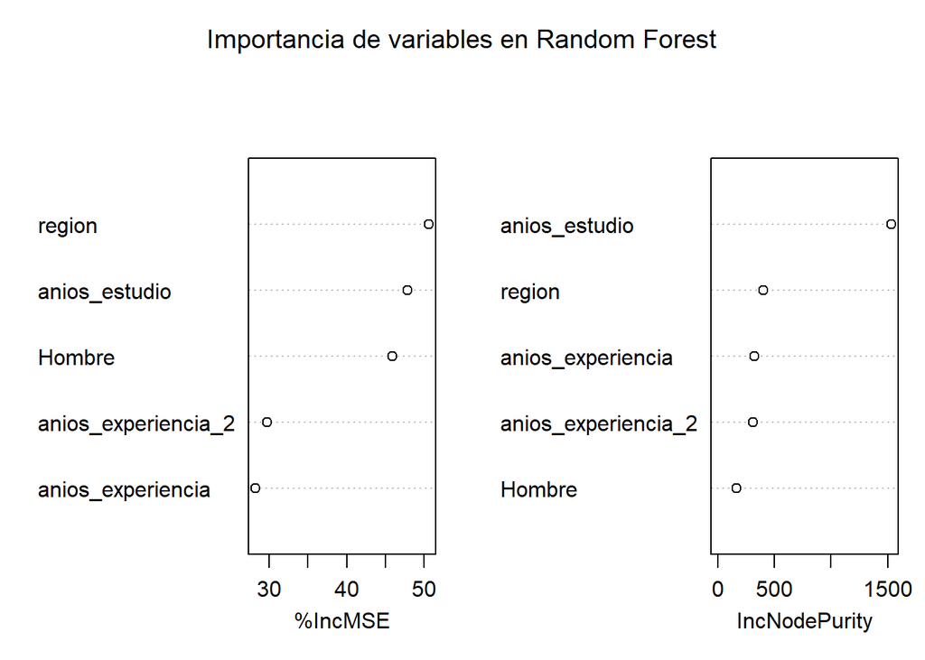

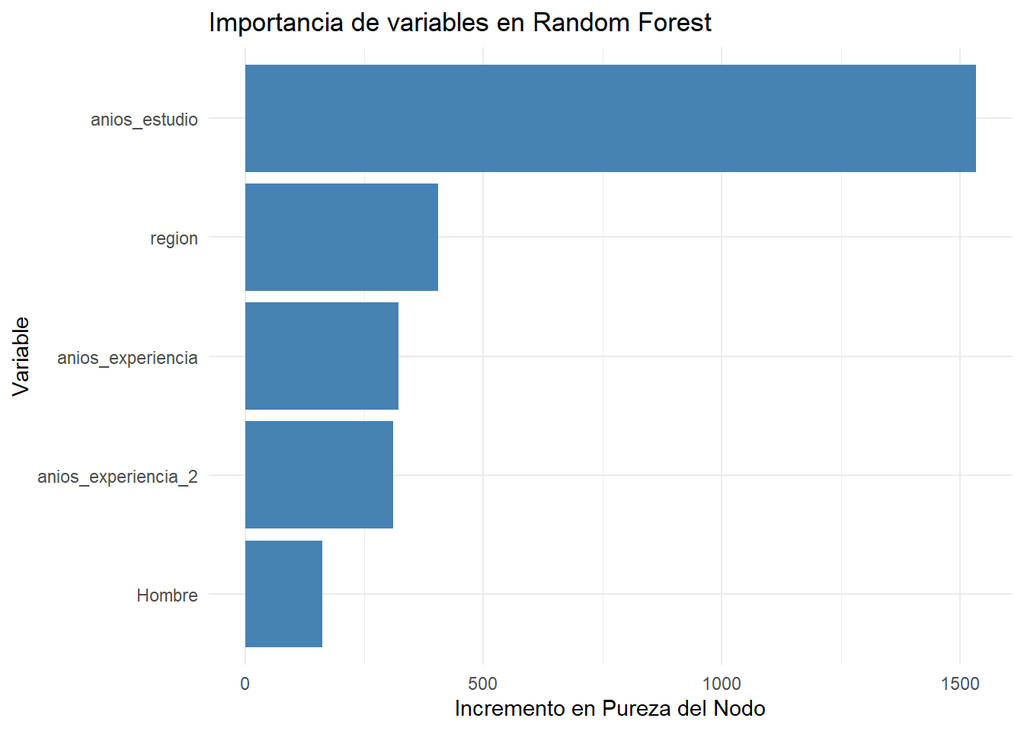

🔍 Requisito técnico en XGBoost: ¿Por qué todas las variables deben ser numéricas? XGBoost, como muchos algoritmos basados en árboles de decisión, requiere que las variables de entrada estén codificadas numéricamente. Esto se debe a que internamente compara valores y realiza divisiones basadas en números, no en categorías textuales.

1. 🎯 One-Hot Encoding (dummies) Ventajas:

Elimina riesgo de relaciones falsas entre categorías.

Compatible con xgboost::xgb.DMatrix().

Desventajas:

Aumenta la dimensionalidad del dataset.

Puede ralentizar el entrenamiento. ### Notas:

En el análisis se probó introducir al variable edad, lo que incrementó el MSE y redujó el % Variación explicada.

Aunque se mantiene la variable Región como categórica, con la región sur como base, el modelo no identifica interacciones que aporten mejeoras a los árboles de regresión.

## ⚡️XGBoost

#### Se considera un algorimo más preciso y eficiente que RM, pero requiere un ajustes en los parámetros lo que agrega dificultad en su implementación.

Resumen del modelo XGBoost

| MSE | **% Var explicada** | *R<sup>2</sup> = 1 - Σ(y - ŷ)² / Σ(y - ȳ)²* |
| --- | --- | --- |
| 0.70548 | 34.53947 | 0.3453535 |

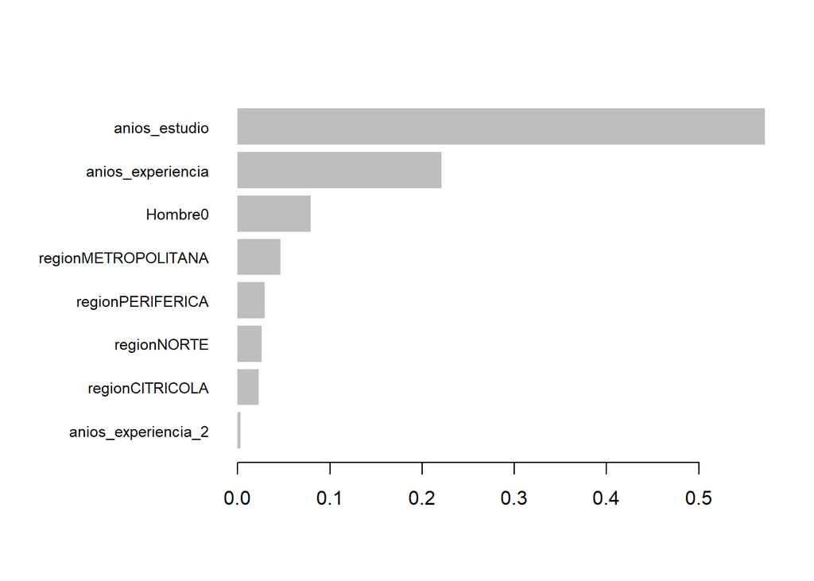

## 🎯 Cómo cambia la predicción esperada al modificar una variable, manteniendo las demás constantes

Prueba con Años de Estudio vs Log(Ingreso mensual) Prueba con Años de experiencia vs Log(Ingreso mensual) 🔁 Bucle (representa el boosting iterativo)

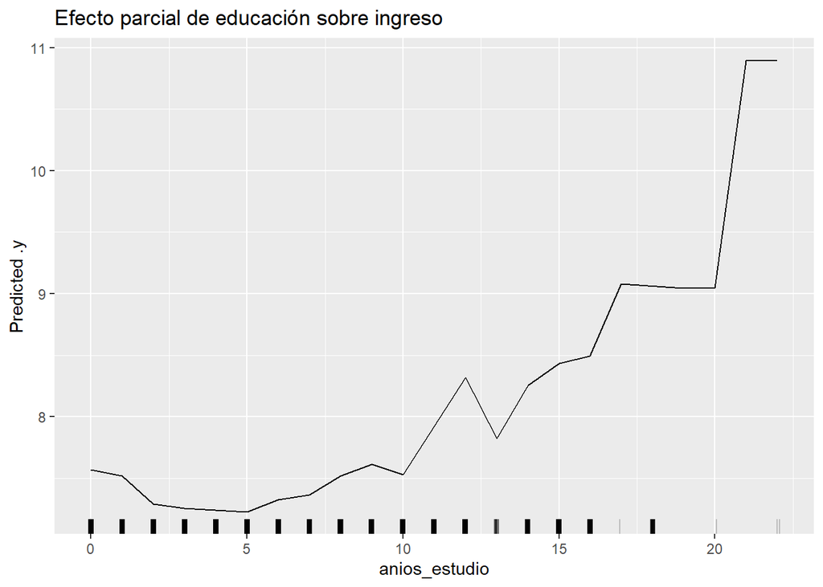

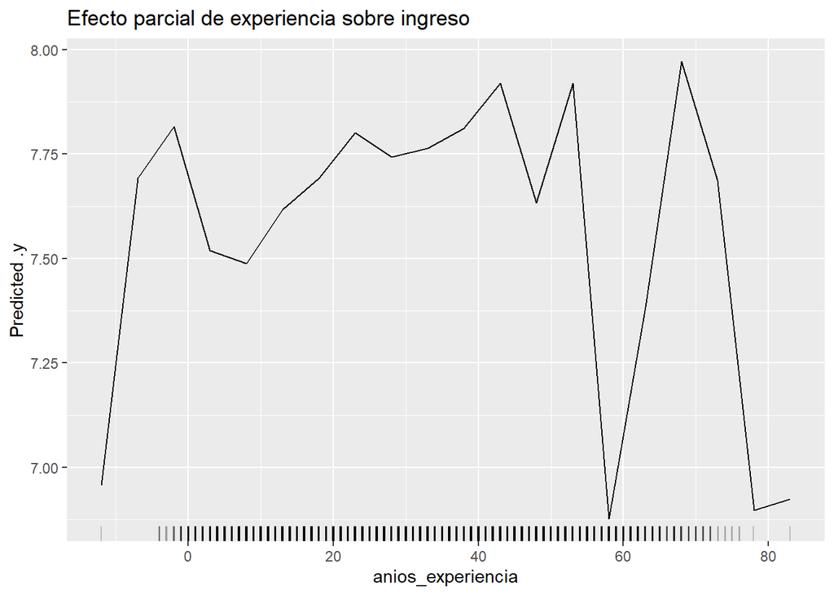

## 🕸️ Nnet

🕸️ Redes Neuronales (nnet) 🧬 ADN (por su estructura de capas complejas)

🧠 Cerebro (símbolo clásico de inteligencia artificial)

🔌 Conexión (por el entramado de nodos sinápticos)

```
##   size decay       mse
## 1    5  0.01 0.8864098
## 2    8  0.01 0.8816399
## 3   10  0.01 0.8871030
## 4    5  0.10 0.8850649
## 5    8  0.10 0.8838384
## 6   10  0.10 0.8813956
## 7    5  0.50 0.8855459
## 8    8  0.50 0.8849319
## 9   10  0.50 0.8842383
```

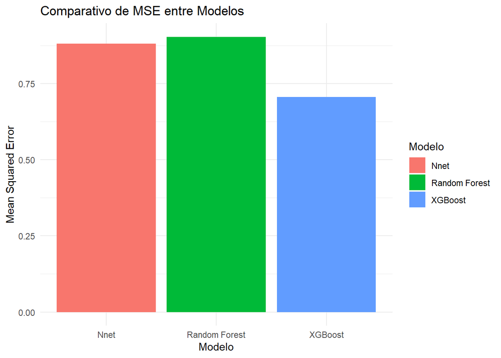

### ->Análisis descriptivo, una mirada a los datos

### ->Volver a la página principal